# Machine Learning no IBGE

31 de agosto de 2019

## Revendo o Dataset

Olá! Seja bem vindo mais uma vez ao dataset de nascimentos e casamentos do IBGE. A base de dados é composta de **4536 observações** e **6 variáveis (estado, ano, faixa etária da mulher, quantidade de nascimentos de bebês do sexo masculino, quantidade de nascimentos de bebês do sexo feminino e quantidade de casamentos**. A *“key”* de cada observação é um conjunto de estado, ano da observação e faixa etária da mulher que casou naquele período ou faixa etária da mãe que teve bebês naquele período. Vamos fazer uma breve revisão, antes de partir para o modelo preditivo.

```r
library(tidyverse)
library(readxl)
casamentos_nascimentosbr<-read_xlsx("C:\\Users\\lferreira\\Downloads\\live university\\Projetos\\casamentos_nascimentosbr.xlsx")

glimpse(casamentos_nascimentosbr)
```

```
## Observations: 4,536
## Variables: 6
## $ estado         <chr> "Acre", "Acre", "Acre", "Acre", "Acre", "Acre",...
## $ ano            <dbl> 2003, 2003, 2003, 2003, 2003, 2003, 2003, 2003,...
## $ classe         <chr> "15 a 19 anos", "20 a 24 anos", "25 a 29 anos",...
## $ nasc_masc      <dbl> 3049, 3692, 2143, 1211, 566, 257, 58, 16, 16, 1...
## $ nasc_fem       <dbl> 2886, 3267, 2059, 1139, 554, 212, 50, 18, 18, 1...
## $ qtd_casamentos <dbl> 410, 685, 493, 340, 184, 129, 66, 52, 27, 19, 2...
```

```r
summary(casamentos_nascimentosbr)
```

```
##     estado               ano          classe            nasc_masc
##  Length:4536        Min.   :2003   Length:4536        Min.   :    0.0
##  Class :character   1st Qu.:2006   Class :character   1st Qu.:   34.0
##  Mode  :character   Median :2010   Mode  :character   Median :  496.5
##                     Mean   :2010                      Mean   : 4809.2
##                     3rd Qu.:2013                      3rd Qu.: 5316.0
##                     Max.   :2016                      Max.   :92918.0
##     nasc_fem     qtd_casamentos
##  Min.   :    0   Min.   :    0
##  1st Qu.:   35   1st Qu.:  140
##  Median :  475   Median :  683
##  Mean   : 4572   Mean   : 2976
##  3rd Qu.: 5054   3rd Qu.: 2924
##  Max.   :87869   Max.   :76407
```

Lembrando que o período das observações vai entre 2003 a 2016. Essa é uma base livre de NA’s!

Vamos nessa análise **elaborar um modelo preditivo que possa para cada estado prever o número de nascimentos, dependendo de variáveis, como faixa etária da mulher e quantidade de casamentos.**

Vamos criar dois modelos de aprendizagem supervisionada a **Regressão Múltipla** e **Random Forest** e decidir qual modelo tem melhor capacidade para prever a quantidade de nascimentos, através de uma das mais famosas medidas de avaliação de desempenho, o **SMAPE!(Symmetric Mean Absolute Percentage Error)**.

Para simplificar, vamos agrupar a quantidade de nascimentos de homens e mulheres em uma variável só!

```r
casamentos_nascimentosbr_ml<-casamentos_nascimentosbr%>%
  group_by(estado,classe,ano)%>%
  summarise(nasc_masc=sum(nasc_masc),nasc_fem=sum(nasc_fem),qtd_casamentos=sum(qtd_casamentos))%>%
  mutate(qtd_nascimentos=nasc_masc+nasc_fem)
#Arrumando as variáveis
 casamentos_nascimentosbr_ml<-casamentos_nascimentosbr_ml[,c(1,2,3,6,7)]
 casamentos_nascimentosbr_ml$estado<-as.factor(casamentos_nascimentosbr_ml$estado)
 casamentos_nascimentosbr_ml$ano<-as.integer(casamentos_nascimentosbr_ml$ano)
  #trocando os valores de classe para numero ordinal
 casamentos_nascimentosbr_ml$classe<-factor(casamentos_nascimentosbr_ml$classe,levels=c(
    "15 a 19 anos","20 a 24 anos","25 a 29 anos","30 a 34 anos",
   "35 a 39 anos","40 a 44 anos","Menos de 15 anos","45 a 49 anos","50 anos ou mais"
 ))
```

Não sei se repararam, mas fiz algo interessante, já que a faixa “menos de 15 anos” possui índice de correlação parecido com as faixas acima de 45 anos, ou seja, sem muito padrão. Para explicar a variável target (Visto em [EDA IBGE](https://rpubs.com/magal1337/EDAIBGE)), **coloquei uma próxima da outra no argumento** `levels`**.** **Isso vai ser crucial para o nosso modelo**.

## Correlação entre quantidade de casamentos e quantidade de nascimentos

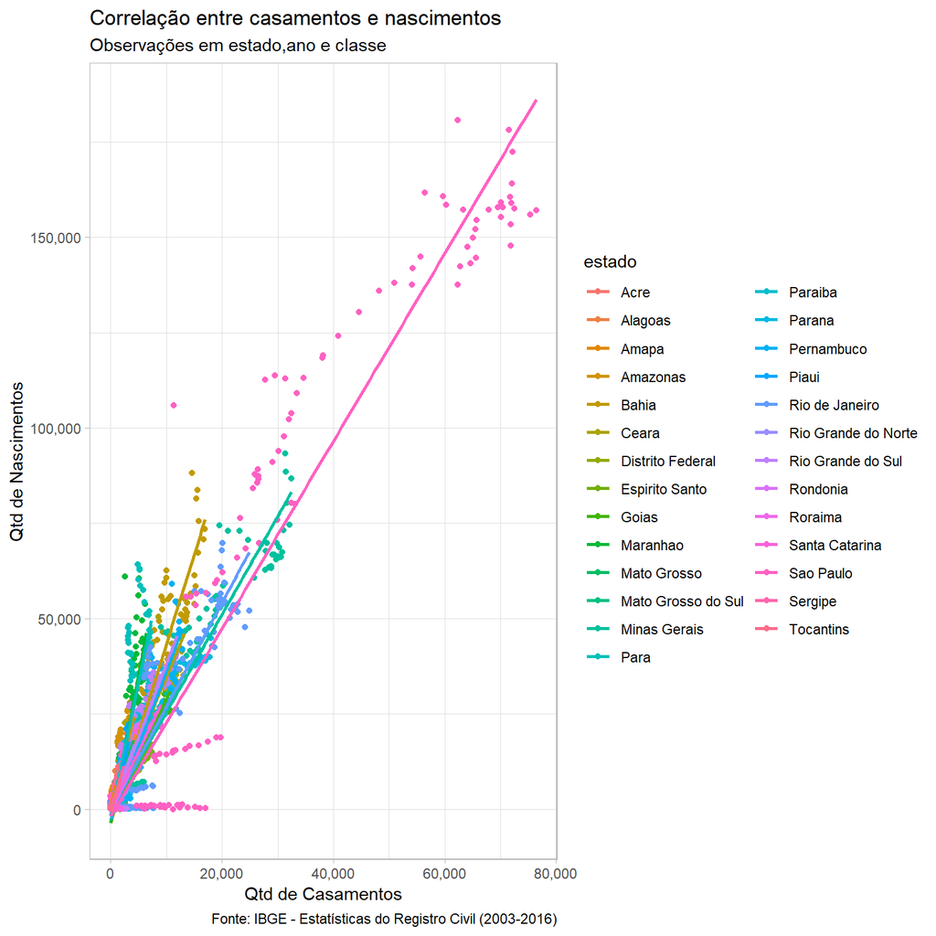

```r
casamentos_nascimentosbr_ml%>%
    ggplot(aes(x=qtd_casamentos,y=qtd_nascimentos,col=estado))+
    geom_point()+
    geom_smooth(method ="lm",se=FALSE)+
    labs(title = "Correlação entre casamentos e nascimentos",subtitle = "Observações em estado,ano e classe",
         caption = "Fonte: IBGE - Estatísticas do Registro Civil (2003-2016)",x="Qtd de Casamentos",
         y="Qtd de Nascimentos")+
    scale_y_continuous(label=scales::comma)+
    scale_x_continuous(label=scales::comma)+
    theme_light()
```

```r
library(GGally)
```

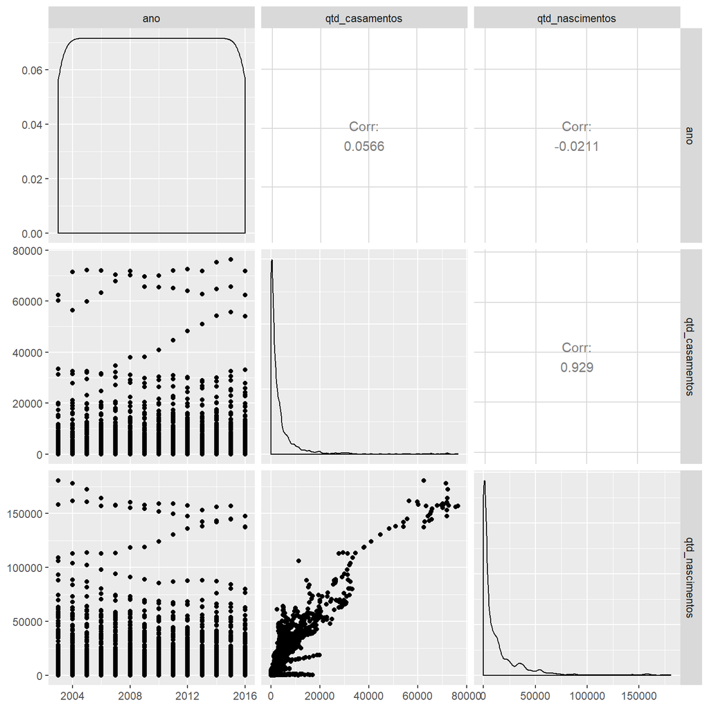

```r
casamentos_nascimentosbr_ml%>%
  ggpairs(3:5)
```

Aparentemente sem multicolinearidade entre as variáveis.

Vamos agrupar o dataset em estado. Gosto muito quando vou elaborar vários modelos de uma vez só usar o purrr e o tidyr package! Principalmente por duas grandes e maravilhosas funções, a `nest()` e a `map()` para trabalhar com listas!

Vamos agrupar e dar uma olhada na correlação entre quantidade de nascimentos e casamentos para cada estado?

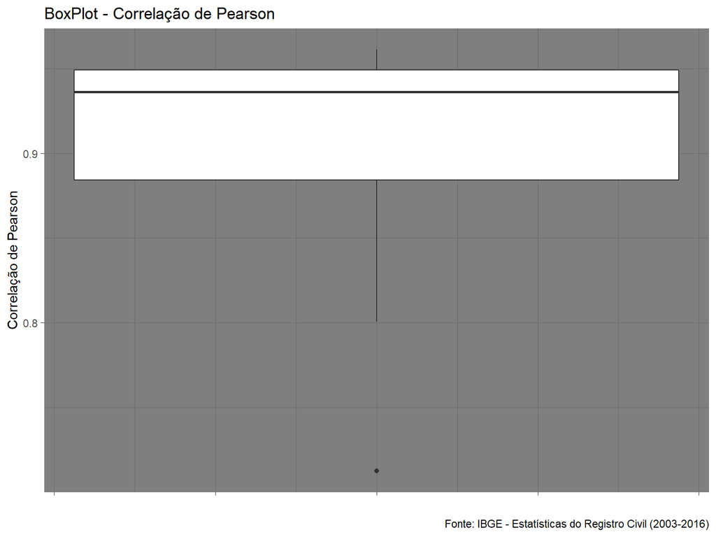

```r
library(purrr)

casamentos_nascimentosbr_ml_nest<-casamentos_nascimentosbr_ml%>%
  group_by(estado)%>%nest()

casamentos_nascimentosbr_ml_nest%>%
  mutate(cor_pearson = map_dbl(.x=data,.f= ~cor(.$qtd_casamentos,.$qtd_nascimentos)))%>%
  ggplot(aes(y=cor_pearson))+
  geom_boxplot()+
  labs(x="",y="Correlação de Pearson",title = "BoxPlot - Correlação de Pearson",
       caption = "Fonte: IBGE - Estatísticas do Registro Civil (2003-2016)")+
  theme_dark()+
  theme(
    axis.text.x = element_blank()
  )
```

Uau! Que poder! Correlação excelente de um modo geral, mas vemos um outlier em nosso boxplot. Qual estado será? Vamos descobrir.

```r
casamentos_nascimentosbr_ml_nest%>%
  mutate(cor_pearson = map_dbl(.x=data,.f= ~cor(.$qtd_casamentos,.$qtd_nascimentos)))%>%
  filter(cor_pearson<.8)
```

| estado | data | cor_pearson |
| --- | --- | --- |
| Amapa |  | 0.7124955 |

Ainda assim uma correlação de 0.71 é excelente! Bem, vamos dar início à modelagem.

## Modelando com Regressão Linear Múltipla

```r
library(rsample) #Criando a partição
set.seed(42)
casamentos_nascimentosbr_ml_split<-casamentos_nascimentosbr_ml_nest%>%
  mutate(split = map(.x=data,.f=~initial_split(.x,prop=0.75))) #vamos fazer uma separação entre treinamento e teste com uma relação 75/25

casamentos_nascimentosbr_ml_split<-casamentos_nascimentosbr_ml_split%>%
  mutate(train_CV = map(.x=split,.f=~training(.x)),test = map(.x=split,.f=~testing(.x)))

head(casamentos_nascimentosbr_ml_split)
```

| estado | data | split | train_CV | test |
| --- | --- | --- | --- | --- |
| Acre |  |  |  |  |
| Alagoas |  |  |  |  |
| Amapa |  |  |  |  |
| Amazonas |  |  |  |  |
| Bahia |  |  |  |  |
| Ceara |  |  |  |  |

Beleza, agora na amostra de treinamento *train_CV* vamos fazer uma validação cruzada criando 5 partições e para cada partição vamos fazer a mesma divisão proporcional entre treinamento e teste.

```r
casamentos_nascimentosbr_ml_split<-casamentos_nascimentosbr_ml_split%>%
  mutate(CV_split = map(.x=train_CV,.f=~vfold_cv(.x,v=5)))

#vamos agora dar unnest e trabalhar com um dataset da validação cruzada a parte para facilitar
# a modelagem
casamentos_nascimentosbr_ml_CV<-casamentos_nascimentosbr_ml_split%>%
 unnest(CV_split)
head(casamentos_nascimentosbr_ml_CV)
```

| estado | splits | id |
| --- | --- | --- |
| Acre |  | Fold1 |
| Acre |  | Fold2 |
| Acre |  | Fold3 |
| Acre |  | Fold4 |
| Acre |  | Fold5 |
| Alagoas |  | Fold1 |

```r
#criando uma amostra de treino e uma de teste para cada partição da validação cruzada
casamentos_nascimentosbr_ml_CV<-casamentos_nascimentosbr_ml_CV%>%
  mutate(
    train = map(splits, ~training(.x)),
    validate = map(splits, ~testing(.x))
  )

head(casamentos_nascimentosbr_ml_CV)
```

| estado | splits | id | train | validate |
| --- | --- | --- | --- | --- |
| Acre |  | Fold1 |  |  |
| Acre |  | Fold2 |  |  |
| Acre |  | Fold3 |  |  |
| Acre |  | Fold4 |  |  |
| Acre |  | Fold5 |  |  |
| Alagoas |  | Fold1 |  |  |

Beleza, tudo certo. Partições criadas, amostras de treinamento e testes prontos. Agora, vamos para a criação do modelo de regressão!

```r
casamentos_nascimentosbr_ml_CV<-casamentos_nascimentosbr_ml_CV%>%
  mutate(model = map(.x=train,.f=~lm(qtd_nascimentos~.,data=.x)))
head(casamentos_nascimentosbr_ml_CV)
```

| estado | splits | id | train | validate | model |
| --- | --- | --- | --- | --- | --- |
| Acre |  | Fold1 |  |  |  |
| Acre |  | Fold2 |  |  |  |
| Acre |  | Fold3 |  |  |  |
| Acre |  | Fold4 |  |  |  |
| Acre |  | Fold5 |  |  |  |
| Alagoas |  | Fold1 |  |  |  |

Vamos ver como ficou nosso R² ajustado, para cada modelo:

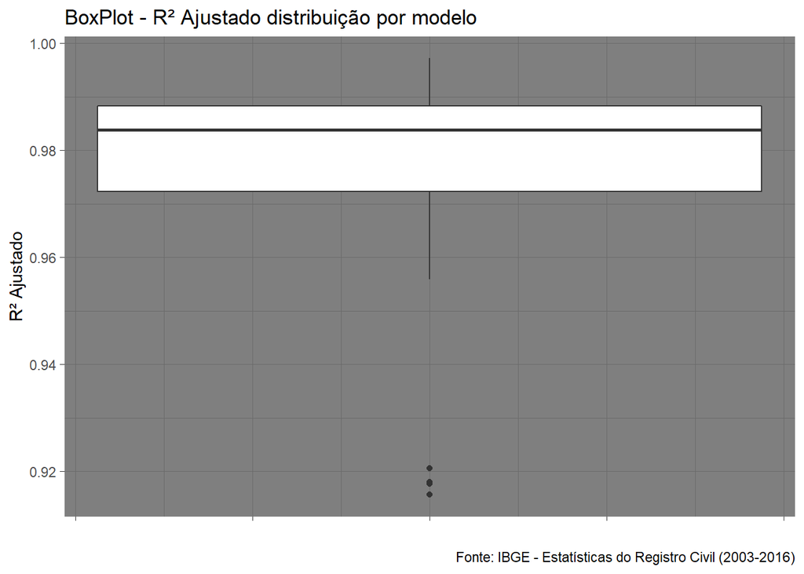

```r
library(broom)
casamentos_nascimentosbr_ml_CV%>%
  mutate(
    rsquad = map_dbl(.x=model,.f=~glance(.x)[["adj.r.squared"]])
  )%>%
  ggplot(aes(y=rsquad))+
  geom_boxplot()+
  labs(x="",y="R² Ajustado",title = "BoxPlot - R² Ajustado distribuição por modelo",
       caption = "Fonte: IBGE - Estatísticas do Registro Civil (2003-2016)")+
  theme_dark()+
  theme(
    axis.text.x = element_blank()
  )
```

Assombroso! Parece que as variáveis do dataset estão conseguindo explicar de forma excelente a variação no fator quantidade de nascimentos. Mas será que o modelo vai ser capaz de prever bem nas amostras de teste da validação cruzada?

Mas antes disso, será que podemos melhorar ainda mais o nosso modelo? Gosto sempre quando trabalho com regressão, pois tento aperfeiçoar o modelo, minimizando o valor do critério de Akaike com a `stepAIC()` função do MASS package.

```r
library(MASS)
```

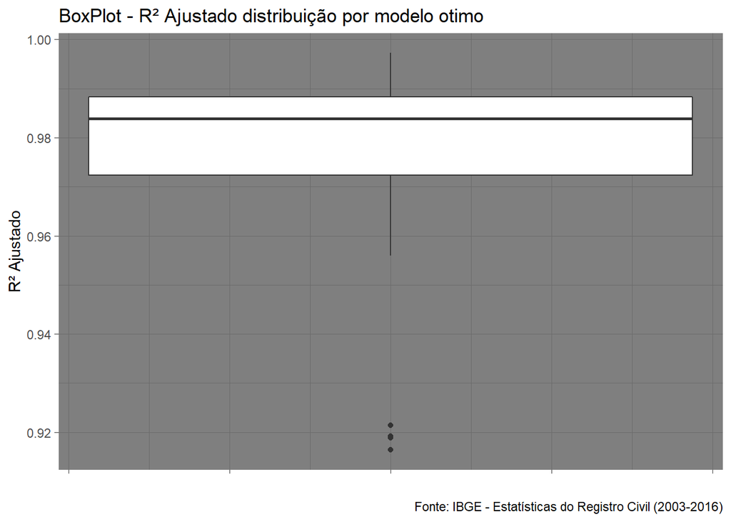

```r
casamentos_nascimentosbr_ml_CV<-casamentos_nascimentosbr_ml_CV%>%
  mutate(model_otimo = map(.x=train,.f=~(lm(qtd_nascimentos~.,data=.x)%>%
  stepAIC(trace=0))
  ))

casamentos_nascimentosbr_ml_CV%>%
  mutate(
    rsquad = map_dbl(.x=model_otimo,.f=~glance(.x)[["adj.r.squared"]])
  )%>%
  ggplot(aes(y=rsquad))+
  geom_boxplot()+
  labs(x="",y="R² Ajustado",title = "BoxPlot - R² Ajustado distribuição por modelo otimo",
       caption = "Fonte: IBGE - Estatísticas do Registro Civil (2003-2016)")+
  theme_dark()+
  theme(
    axis.text.x = element_blank()
  )
```

Como o modelo já tinha um nível muito bom, não tivemos uma diferença significativa entre eles.

Mas vamos seguir com ambos os modelos para validação com o SMAPE!

```r
casamentos_nascimentosbr_ml_CV<-casamentos_nascimentosbr_ml_CV%>%
  mutate(

    validate_actual = map(validate, ~.x$qtd_nascimentos),

    validate_predicted = map2(.x = model_otimo, .y = validate, ~predict(.x, .y))

  )

head(casamentos_nascimentosbr_ml_CV)
```

| estado | splits | id | train | validate | model | model_otimo | validate_actual | validate_predicted |
| --- | --- | --- | --- | --- | --- | --- | --- | --- |
| Acre |  | Fold1 |  |  |  |  |  |  |
| Acre |  | Fold2 |  |  |  |  |  |  |
| Acre |  | Fold3 |  |  |  |  |  |  |
| Acre |  | Fold4 |  |  |  |  |  |  |
| Acre |  | Fold5 |  |  |  |  |  |  |
| Alagoas |  | Fold1 |  |  |  |  |  |  |

```r
library(Metrics)
casamentos_nascimentosbr_ml_CV<-casamentos_nascimentosbr_ml_CV%>%
  mutate(validate_smape = map2_dbl(
    .x=validate_actual,.y= validate_predicted,.f= ~smape(actual = .x, predicted = .y)))

casamentos_nascimentosbr_SMAPE<-casamentos_nascimentosbr_ml_CV%>%
  group_by(estado)%>%
  summarise(SMAPE = mean(validate_smape))

library(knitr)

kable(casamentos_nascimentosbr_SMAPE)
```

| estado | SMAPE |
| --- | --- |
| Acre | 0.3887492 |
| Alagoas | 0.5712747 |
| Amapa | 0.2981771 |
| Amazonas | 0.2281959 |
| Bahia | 0.3931730 |
| Ceara | 0.3372935 |
| Distrito Federal | 0.5070146 |
| Espirito Santo | 0.4344515 |
| Goias | 0.4022064 |
| Maranhao | 0.5761041 |
| Mato Grosso | 0.5559720 |
| Mato Grosso do Sul | 0.2549416 |
| Minas Gerais | 0.4231878 |
| Para | 0.4897178 |
| Paraiba | 0.5985835 |
| Parana | 0.3032747 |
| Pernambuco | 0.5397053 |
| Piaui | 0.5579125 |
| Rio de Janeiro | 0.3641744 |
| Rio Grande do Norte | 0.5528111 |
| Rio Grande do Sul | 0.3324656 |
| Rondonia | 0.4961022 |
| Roraima | 0.3739956 |
| Santa Catarina | 0.4287751 |
| Sao Paulo | 0.3742262 |
| Sergipe | 0.4243968 |
| Tocantins | 0.6402341 |

Ops! Tivemos um overfitting, parece que na amostra de treinamento, os fatores conseguem explicar muito bem a variação do fator quantidade de nascimentos, mas para previsão fora da amostra o desempenho ficou muito abaixo do esperado!

Vamos tentar então simplificar o modelo, vamos usar somente as variaveis qtd_casamentos e classe, como variáveis explicativas dessa vez!

```r
casamentos_nascimentosbr_ml_CV<-casamentos_nascimentosbr_ml_CV%>%
  mutate(model2 = map(.x=train,.f=~lm(qtd_nascimentos~qtd_casamentos+classe,data=.x)))

casamentos_nascimentosbr_ml_CV<-casamentos_nascimentosbr_ml_CV%>%
  mutate(



    validate_predicted2 = map2(.x = model2, .y = validate, ~predict(.x, .y))

  )


casamentos_nascimentosbr_ml_CV<-casamentos_nascimentosbr_ml_CV%>%
  mutate(validate_smape2 = map2_dbl(
    .x=validate_actual,.y= validate_predicted2,.f= ~smape(actual = .x, predicted = .y)))

casamentos_nascimentosbr_SMAPE2<-casamentos_nascimentosbr_ml_CV%>%
  group_by(estado)%>%
  summarise(SMAPE2 = mean(validate_smape2))

kable(casamentos_nascimentosbr_SMAPE2)
```

| estado | SMAPE2 |
| --- | --- |
| Acre | 0.1595873 |
| Alagoas | 0.2918275 |
| Amapa | 0.1024682 |
| Amazonas | 0.2281959 |
| Bahia | 0.3982810 |
| Ceara | 0.2408246 |
| Distrito Federal | 0.3484189 |
| Espirito Santo | 0.4613920 |
| Goias | 0.3935993 |
| Maranhao | 0.2459672 |
| Mato Grosso | 0.4792189 |
| Mato Grosso do Sul | 0.2568969 |
| Minas Gerais | 0.3032223 |
| Para | 0.3121873 |
| Paraiba | 0.3066841 |
| Parana | 0.3465375 |
| Pernambuco | 0.1713558 |
| Piaui | 0.4822571 |
| Rio de Janeiro | 0.3196625 |
| Rio Grande do Norte | 0.3531862 |
| Rio Grande do Sul | 0.4519925 |
| Rondonia | 0.3262205 |
| Roraima | 0.2561849 |
| Santa Catarina | 0.4305370 |
| Sao Paulo | 0.3216776 |
| Sergipe | 0.3051049 |
| Tocantins | 0.3521932 |

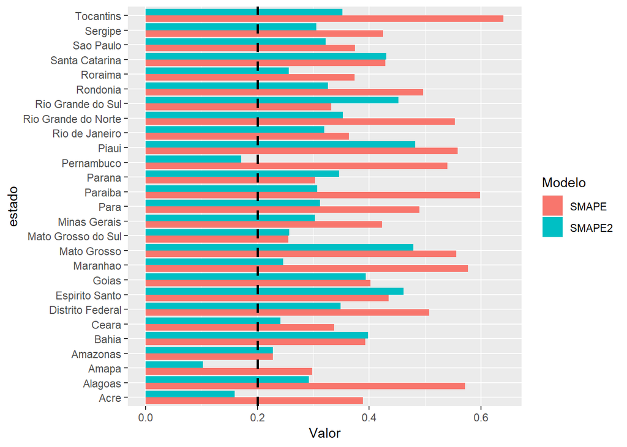

```r
analise_SMAPE<-full_join(casamentos_nascimentosbr_SMAPE,casamentos_nascimentosbr_SMAPE2,by="estado")

analise_SMAPE%>%gather(Modelo,Valor,2:3)%>%
  ggplot(aes(x=estado,y=Valor,fill=Modelo))+
  geom_col(position = "dodge")+
  geom_hline(yintercept = .2,linetype = "dashed",col = "black",size=1)+
  coord_flip()
```

Parece que o modelo 2 mais simples, teve um efeito preditivo melhor.

Vamos finalizar fazendo calculo na amostra de teste que separamos no inicio da modelagem.

```r
casamentos_nascimentosbr_ml_reg<-full_join(
 casamentos_nascimentosbr_ml_split,
  analise_SMAPE,
  by="estado")

#facilitar a leitura
casamentos_nascimentosbr_ml_reg<-casamentos_nascimentosbr_ml_reg[,c(1,4,5,7,8)]

head(casamentos_nascimentosbr_ml_reg)
```

| estado | train_CV | test | SMAPE | SMAPE2 |
| --- | --- | --- | --- | --- |
| Acre |  |  | 0.3887492 | 0.1595873 |
| Alagoas |  |  | 0.5712747 | 0.2918275 |
| Amapa |  |  | 0.2981771 | 0.1024682 |
| Amazonas |  |  | 0.2281959 | 0.2281959 |
| Bahia |  |  | 0.3931730 | 0.3982810 |
| Ceara |  |  | 0.3372935 | 0.2408246 |

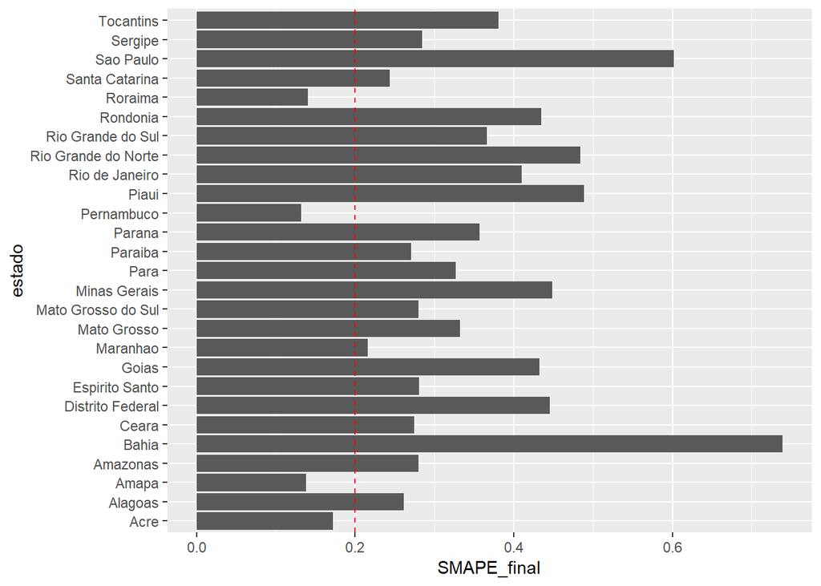

```r
#criando o modelo melhor para cada estado
casamentos_nascimentosbr_ml_reg<-casamentos_nascimentosbr_ml_reg%>%
  mutate(best_model = if_else(

  SMAPE<SMAPE2,"MODEL1","MODEL2"

  ))


casamentos_nascimentosbr_ml_reg<-casamentos_nascimentosbr_ml_reg%>%
  mutate(model =if_else(best_model=="MODEL1",
   map(.x=train_CV,.f=~(lm(
   qtd_nascimentos~.,data=.x)%>%
   stepAIC(trace=0))),
   map(.x=train_CV,
  .f=~lm(qtd_nascimentos~qtd_casamentos+classe,data=.x))))

casamentos_nascimentosbr_ml_reg<-casamentos_nascimentosbr_ml_reg%>%
  mutate(

    validate_actual = map(test, ~.x$qtd_nascimentos),

    validate_predicted = map2(.x = model, .y = test, ~predict(.x, .y))

  )


casamentos_nascimentosbr_ml_reg<-casamentos_nascimentosbr_ml_reg%>%
  mutate(SMAPE_final = map2_dbl(
    .x=validate_actual,.y= validate_predicted,.f= ~smape(actual = .x, predicted = .y)))


 ggplot(casamentos_nascimentosbr_ml_reg,aes(x=estado,y=SMAPE_final))+
   geom_col()+
   geom_hline(yintercept = .2,linetype="dashed",col="red")+
   coord_flip()
```

```r
  casamentos_nascimentosbr_ml_reg%>%
   count(SMAPE_final<=.2)%>%
    kable()
```

| SMAPE_final <= 0.2 | n |
| --- | --- |
| FALSE | 23 |
| TRUE | 4 |

Bem, amenizamos um pouco a situação, mas ainda temos 23 modelos com um SMAPE maior do que 20%. Inaceitável!

Será que conseguimos algo melhor com o Random Forest?

## Modelando com Random Forest (Floresta Aleatória)

Vamos manter a mesma partição da validação cruzada usada na regressão. No nosso modelo, para facilitar o processamento vamos deixar o número de árvores em 100. Acredito que já seja um valor razoável para criação de um bom modelo. Para o parâmetro mtry, vamos inserir todas as possibilidades de um a três fatores, usando a função `crossing()` assim vamos saber qual o parâmetro mtry terá o melhor desempenho.

```r
library(ranger)
  casamentos_nascimentosbr_ml_CV2<-casamentos_nascimentosbr_ml_CV[,1:5]

  casamentos_nascimentosbr_ml_tune<-casamentos_nascimentosbr_ml_CV2%>%
    crossing(mtry=1:3)

  #random forest para cada combinação de estado, fold e mtry
  casamentos_nascimentosbr_ml_tune<-casamentos_nascimentosbr_ml_tune%>%
    mutate(
      model = map2(.x=train,.y=mtry,.f= ~ranger(formula=qtd_nascimentos~.,data= .x,
      num.trees=100,seed = 42,mtry = .y))

    )

  casamentos_nascimentosbr_ml_tune<-casamentos_nascimentosbr_ml_tune%>%
    mutate(
      validate_predicted = map2(.x = model, .y = validate, ~predict(.x, .y)$predictions))

  casamentos_nascimentosbr_ml_tune<-casamentos_nascimentosbr_ml_tune%>%
    mutate(
      validate_actual = map(.x=validate,.f= ~.x$qtd_nascimentos))

  casamentos_nascimentosbr_ml_tune<-casamentos_nascimentosbr_ml_tune%>%
    mutate(validate_smape = map2_dbl(.x=validate_actual,
   .y=validate_predicted, .f= ~smape(actual = .x, predicted = .y)))

  casamentos_nascimentosbr_ml_rf<-casamentos_nascimentosbr_ml_tune%>%
    group_by(estado,mtry)%>%
    summarise(SMAPE = mean(validate_smape))


  kable(casamentos_nascimentosbr_ml_rf)
```

| estado | mtry | SMAPE |
| --- | --- | --- |
| Acre | 1 | 0.3589207 |
| Acre | 2 | 0.1748306 |
| Acre | 3 | 0.1395432 |
| Alagoas | 1 | 0.3611932 |
| Alagoas | 2 | 0.1563820 |
| Alagoas | 3 | 0.1311870 |
| Amapa | 1 | 0.4470668 |
| Amapa | 2 | 0.1810180 |
| Amapa | 3 | 0.1005982 |
| Amazonas | 1 | 0.2980661 |
| Amazonas | 2 | 0.1835755 |
| Amazonas | 3 | 0.1430832 |
| Bahia | 1 | 0.3672615 |
| Bahia | 2 | 0.1383488 |
| Bahia | 3 | 0.0892367 |
| Ceara | 1 | 0.3687329 |
| Ceara | 2 | 0.1077914 |
| Ceara | 3 | 0.0720162 |
| Distrito Federal | 1 | 0.3744352 |
| Distrito Federal | 2 | 0.1673408 |
| Distrito Federal | 3 | 0.1406324 |
| Espirito Santo | 1 | 0.4180209 |
| Espirito Santo | 2 | 0.1943504 |
| Espirito Santo | 3 | 0.1405170 |
| Goias | 1 | 0.4384444 |
| Goias | 2 | 0.1527381 |
| Goias | 3 | 0.0843674 |
| Maranhao | 1 | 0.3243044 |
| Maranhao | 2 | 0.2044007 |
| Maranhao | 3 | 0.1757804 |

[output cut: 51 more lines]

```r
   casamentos_nascimentosbr_ml_rf2<-casamentos_nascimentosbr_ml_tune%>%
    group_by(mtry)%>%
    summarise(SMAPE = mean(validate_smape))

   kable(casamentos_nascimentosbr_ml_rf2)
```

| mtry | SMAPE |
| --- | --- |
| 1 | 0.3879070 |
| 2 | 0.1780614 |
| 3 | 0.1232545 |

Hum, parece que o parâmetro `mtry(3)` foi o melhor entre os demais. Vamos continuar com a amostra de teste final.

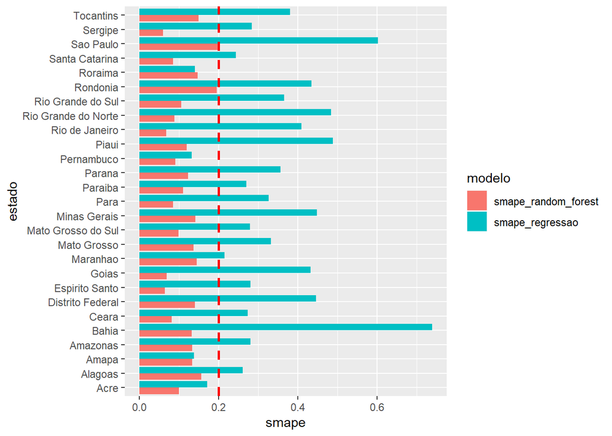

```r
casamentos_nascimentos_br_rf<-casamentos_nascimentosbr_ml_split[,c(1,4,5)]

  casamentos_nascimentos_br_rf<-casamentos_nascimentos_br_rf%>%
   mutate(

     model = map(.x=train_CV,.f= ~ranger(formula=qtd_nascimentos~.,data= .x,
                                               num.trees=100,seed = 42,mtry = 3))

   )

  casamentos_nascimentos_br_rf<-casamentos_nascimentos_br_rf%>%
    mutate(
      validate_predicted = map2(.x = model, .y = test, ~predict(.x, .y)$predictions))
  casamentos_nascimentos_br_rf<-casamentos_nascimentos_br_rf%>%
    mutate(
      validate_actual = map(.x=test,.f= ~.x$qtd_nascimentos))


  casamentos_nascimentos_br_rf<-casamentos_nascimentos_br_rf%>%
    mutate(validate_smape = map2_dbl(.x=validate_actual,
                                    .y=validate_predicted, .f= ~smape(actual = .x, predicted = .y)))

#comparando os MAPE de Regressão multipla e random forest

  smape_ml_models<-full_join(casamentos_nascimentosbr_ml_reg[,c(1,10)],
  casamentos_nascimentos_br_rf[,c(1,7)],by="estado")
    colnames(smape_ml_models)<-c("estado","smape_regressao","smape_random_forest")
  smape_ml_models2<-smape_ml_models%>%
    gather(modelo,smape,2:3)
  ggplot(smape_ml_models2,aes(x=estado,y=smape,fill=modelo))+
    geom_col(position = "dodge")+
    geom_hline(yintercept = .2,linetype="dashed",col="red",size=1)+
    coord_flip()
```

```r
  kable(smape_ml_models)
```

| estado | smape_regressao | smape_random_forest |
| --- | --- | --- |
| Acre | 0.1719814 | 0.1007378 |
| Alagoas | 0.2613108 | 0.1562917 |
| Amapa | 0.1384032 | 0.1333460 |
| Amazonas | 0.2802289 | 0.1339450 |
| Bahia | 0.7389492 | 0.1326222 |
| Ceara | 0.2744310 | 0.0823935 |
| Distrito Federal | 0.4457913 | 0.1407420 |
| Espirito Santo | 0.2810086 | 0.0641352 |
| Goias | 0.4321118 | 0.0691178 |
| Maranhao | 0.2156510 | 0.1449370 |
| Mato Grosso | 0.3324441 | 0.1373863 |
| Mato Grosso do Sul | 0.2798702 | 0.0994778 |
| Minas Gerais | 0.4489222 | 0.1416210 |
| Para | 0.3266229 | 0.0853473 |
| Paraiba | 0.2707645 | 0.1102267 |
| Parana | 0.3571254 | 0.1230340 |
| Pernambuco | 0.1320879 | 0.0910613 |
| Piaui | 0.4885375 | 0.1200653 |
| Rio de Janeiro | 0.4097590 | 0.0680517 |
| Rio Grande do Norte | 0.4838143 | 0.0891332 |
| Rio Grande do Sul | 0.3658414 | 0.1058016 |
| Rondonia | 0.4347397 | 0.1958627 |
| Roraima | 0.1405856 | 0.1474623 |
| Santa Catarina | 0.2438924 | 0.0857926 |
| Sao Paulo | 0.6021793 | 0.2003700 |
| Sergipe | 0.2844346 | 0.0601751 |
| Tocantins | 0.3809025 | 0.1497633 |

```r
  smape_ml_models%>%
    count(smape_regressao<smape_random_forest)
```

| smape_regressao < smape_random_forest | n |
| --- | --- |
| FALSE | 26 |
| TRUE | 1 |

```r
  smape_ml_models2%>%
    filter(modelo == "smape_regressao")%>%
    count(smape<=.2)
```

| smape <= 0.2 | n |
| --- | --- |
| FALSE | 23 |
| TRUE | 4 |

```r
  smape_ml_models2%>%
    filter(modelo == "smape_random_forest")%>%
    count(smape<=.2)
```

| smape <= 0.2 | n |
| --- | --- |
| FALSE | 1 |
| TRUE | 26 |

```r
  mean(smape_ml_models$smape_random_forest)
```

```
## [1] 0.1173667
```

Excelente, exceto pelo estado de Roraima, o modelo de Random Forest foi superior! Mesmo assim a diferença do estado de Roraima foi muito pequena e podemos dizer que tivemos para todos os estados com o modelo de Random Forest um SMAPE menor do que 21% com média de 11,7%!

Como fizemos uma análise exploratória de dados no artigo anterior, descobrimos que para faixas etárias “menos de 15 anos” e para classes acima de 45 anos possuem comportamento muito parecido. Não temos tanto padrão só com número de casamentos, o que faz todo sentido, correto? Precisaríamos de mais variáveis para tentar explicar o número de nascimentos para essas classes. Poderíamos até agrupar essas classes em uma só, para nossa modelagem (ex: Faixas etárias fora do intervalo 15-44). Mas achei melhor deixá-las próximas no argumento `levels()`. Sem esse conhecimento de “ordem”, se colocássemos o argumento classe, somente com ordem de idade, obteríamos um modelo muito pior, com média do smape em torno de 50%! Por este motivo, sempre acho válido analisar bem o dataset antes para descobrir insights valiosos para modelagem!

## Final: Previsão para 2017

Vamos agora importar o dataset de casamentos_nascimentosbr_2017 para incrementar nossa base de dados atual, e ver o quanto nosso modelo acerta para o ano de 2017!

```r
casamentos_nascimentosbr_2017<-read_xlsx("C:\\Users\\lferreira\\Downloads\\live university\\casamentos_nascimentosbr_2017.xlsx")

casamentos_nascimentosbr_2017<- casamentos_nascimentosbr_2017%>%
  mutate(
    estado = as.factor(estado),
    classe = factor(classe,levels = c( "15 a 19 anos","20 a 24 anos","25 a 29 anos","30 a 34 anos",
   "35 a 39 anos","40 a 44 anos","Menos de 15 anos","45 a 49 anos","50 anos ou mais"
 )),
    ano = as.integer(ano)
  )

casamentos_nascimentosbr_ml2<-bind_rows(casamentos_nascimentosbr_ml,casamentos_nascimentosbr_2017)

casamentos_nascimentosbr_ml2_nest<-casamentos_nascimentosbr_ml2%>%
  group_by(estado)%>%nest()

casamentos_nascimentosbr_ml2_nest<-casamentos_nascimentosbr_ml2_nest%>%
  mutate(train = map(.x=data,.f=~.x%>%
        filter(ano<2017)),
        validate = map(.x=data,.f=~.x%>%
        filter(ano>=2017))
                     )

casamentos_nascimentosbr_ml2_nest<-casamentos_nascimentosbr_ml2_nest%>%
  mutate( model = map(.x=train,.f=~ranger(formula=qtd_nascimentos~.,data= .x,
                                               num.trees=100,seed = 42,mtry = 3)))

casamentos_nascimentosbr_ml2_nest<-casamentos_nascimentosbr_ml2_nest%>%
  mutate( validate_predicted = map2(.x = model, .y = validate, ~predict(.x, .y)$predictions),
      validate_actual = map(.x=validate,.f= ~.x$qtd_nascimentos))

casamentos_nascimentosbr_ml2_nest<-casamentos_nascimentosbr_ml2_nest%>%
    mutate(validate_smape = map2_dbl(.x=validate_actual,
                                    .y=validate_predicted, .f= ~smape(actual = .x, predicted = .y)))

casamentos_nascimentosbr_ml2_result<-casamentos_nascimentosbr_ml2_nest[,c(1,8)]

 casamentos_nascimentosbr_ml2_result%>%
  kable()
```

| estado | validate_smape |
| --- | --- |
| Acre | 0.3075230 |
| Alagoas | 0.3329709 |
| Amapa | 0.3062975 |
| Amazonas | 0.3999786 |
| Bahia | 0.2596776 |
| Ceara | 0.3059167 |
| Distrito Federal | 0.2922559 |
| Espirito Santo | 0.3011266 |
| Goias | 0.3084185 |
| Maranhao | 0.3512116 |
| Mato Grosso | 0.3725225 |
| Mato Grosso do Sul | 0.3492735 |
| Minas Gerais | 0.2480678 |
| Para | 0.4205127 |
| Paraiba | 0.2303846 |
| Parana | 0.3050680 |
| Pernambuco | 0.3033716 |
| Piaui | 0.2682199 |
| Rio de Janeiro | 0.2337834 |
| Rio Grande do Norte | 0.3042838 |
| Rio Grande do Sul | 0.2649118 |
| Rondonia | 0.2856358 |
| Roraima | 0.3543977 |
| Santa Catarina | 0.2950892 |
| Sao Paulo | 0.2328368 |
| Sergipe | 0.3018810 |
| Tocantins | 0.3072274 |

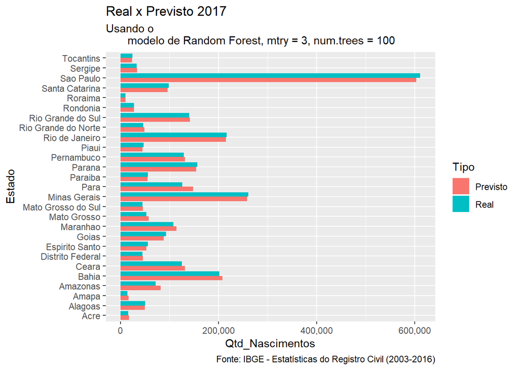

```r
analise_2017<-casamentos_nascimentosbr_ml2_nest[,c(1,6,7)]%>%
  unnest(validate_actual,validate_predicted)%>%
  group_by(estado)%>%
  summarise(Real = sum(validate_actual),Previsto = sum(validate_predicted))%>%
  gather(Tipo,Valor,2:3)

  ggplot(analise_2017,aes(x=estado,y=Valor,fill=Tipo))+
  geom_col(position = "dodge")+
  labs(x="Estado",y="Qtd_Nascimentos",title = "Real x Previsto 2017",subtitle= "Usando o
       modelo de Random Forest, mtry = 3, num.trees = 100",
       caption = "Fonte: IBGE - Estatísticas do Registro Civil (2003-2016)")+
    scale_y_continuous(label=scales::comma)+
  coord_flip()
```

```r
  casamentos_nascimentosbr_ml2_nest[,c(1,6,7)]%>%
  unnest(validate_actual,validate_predicted)%>%
  group_by(estado)%>%
  summarise(Real = sum(validate_actual),Previsto = sum(validate_predicted))%>%
    kable()
```

| estado | Real | Previsto |
| --- | --- | --- |
| Acre | 15485 | 17146.217 |
| Alagoas | 49761 | 49214.526 |
| Amapa | 14190 | 16230.002 |
| Amazonas | 71508 | 81577.706 |
| Bahia | 201243 | 207638.049 |
| Ceara | 125243 | 131107.304 |
| Distrito Federal | 44613 | 45322.897 |
| Espirito Santo | 55999 | 52887.074 |
| Goias | 93016 | 88091.148 |
| Maranhao | 107889 | 114149.652 |
| Mato Grosso | 52258 | 57247.472 |
| Mato Grosso do Sul | 44518 | 45418.918 |
| Minas Gerais | 260630 | 257913.451 |
| Para | 125666 | 147683.171 |
| Paraiba | 56024 | 55034.058 |
| Parana | 156208 | 154528.146 |
| Pernambuco | 129168 | 131462.686 |
| Piaui | 46815 | 44701.125 |
| Rio de Janeiro | 216315 | 214493.788 |
| Rio Grande do Norte | 45926 | 48791.979 |
| Rio Grande do Sul | 140185 | 141701.828 |
| Rondonia | 27543 | 26990.190 |
| Roraima | 9875 | 9611.608 |
| Santa Catarina | 98136 | 95526.083 |
| Sao Paulo | 611097 | 602944.658 |
| Sergipe | 32971 | 33450.128 |
| Tocantins | 24275 | 23472.081 |

Bem próximo da realidade não acha?

Chegamos ao fim! Não criamos o melhor modelo do mundo, mas foi bastante eficiente!

Acredito que possamos explorar mais esses dados na busca de variáveis que ajudam a explicar melhor a quantidade de nascimentos, principalmente para classes fora do arco 15-44 anos.

Mas foi bacana não é?

Obrigado por ter tido paciência para chegar até aqui! Foi uma longa jornada!

Abraços! Sucesso e até a próxima!